# final_R_reference.Rmd

Jordan Smith

2022-11-30

# R Reference Guide

## Loading Data and Packages

**library() and require() functions - both load packages into R**

```r
require("here")
library("palmerpenguins")

ginkgo_df = read.csv(here("data", "ginkgo_data_2022.csv"))
```

## Data Structures

**c() function - combines its elements into a vector.**

- all data must be the same type (characters and numeric cannot be combined in one c()).

```r
# Numeric Vector
numeric_vec = c(1, 10, 100, 1000, 10000)

# Character Vector
charac_vec = c("Monday", "Tuesday", "Wednesday", "Thursday", "Friday")
```

- Typing the name of the vector or using the print() function will output the contents of the vector.

```r
numeric_vec
```

```
## [1]     1    10   100  1000 10000
```

```r
print(charac_vec)
```

```
## [1] "Monday"    "Tuesday"   "Wednesday" "Thursday"  "Friday"
```

**length() function - specifies the length of a vector or the number of elements in a list or matrix.**

```r
length(numeric_vec)
```

```
## [1] 5
```

```r
ex_matrix = matrix(1:9, byrow = TRUE, nrow = 3)
length(ex_matrix)
```

```
## [1] 9
```

**matrix() function - combines elements into a matrix (2D method of grouping elements into rows and columns).**

- can be creating using the matrix() function directly or creating a new matrix using information contained within a vector. The code below will both form a matrix containing values 1-9 with 3 rows and 3 columns

```r
# Using the matrix() function directly
ex_matrix = matrix(1:9, byrow = TRUE, nrow = 3)

# Making a matrix from a vector(s)
vec_one = c(1, 2, 3)
vec_two = c(4, 5, 6)
vec_three = c(7, 8, 9)
vector = c(vec_one, vec_two, vec_three)
matrix = matrix(vector, byrow = TRUE, nrow = 3)

#   First Argument - collection of elements that will be arranged
#   Second Argument - if the matrix will be defined by rows (byrow = TRUE) or columns (byrow = FALSE)
#  Third Argument - indicates the number of rows/columns the matrix will have
```

**data.frame() function - combines the properties of matrices and lists and organizes data into different categories that can be easily identified and named.**

- can have different types of data in it but each column must contain the same type of data.
- nrow()/ncol() function - returns the number of rows/columns present in the specified data frame.

```r
nrow(ginkgo_df)
```

```
## [1] 220
```

```r
ncol(ginkgo_df)
```

```
## [1] 6
```

- dim() function - returns the dimensions of the specified data frame.

```r
dim(ginkgo_df)
```

```
## [1] 220   6
```

## Subsetting

**“$” is used to subset different columns in data frames.**

```r
# Subsetting the data frame by name using $ (notch_depth)
ginkgo_df$notch_depth
```

```
##   [1] 12.0  0.0  0.0  0.0  5.0  7.0  2.0  0.0  3.0  9.0  4.0  3.0  3.0  6.0  2.0
##  [16] 16.0  6.0 10.0  1.0  7.0  4.0  2.0  0.0  1.0  1.0  0.0  2.0  1.0  2.0  0.0
##  [31]  2.0  1.0  2.0  4.0  1.0  5.0  1.0 19.0 27.0  1.0 14.0  6.0  1.0  9.0  5.0
##  [46]  3.0 12.0  4.0 21.0  2.0  1.0  0.5  2.0  3.0  0.5  2.5  1.0  3.0  3.0  0.0
##  [61]  0.0  5.0  0.0  4.0  0.0  0.0  0.0 15.0  0.0  9.0  0.0  0.0  2.0  4.0  0.0
##  [76]  0.0  1.0  8.0  3.0  0.0  0.0 10.0  0.0  0.0  0.0  9.0  0.0  0.0  0.0  0.0
##  [91]  5.0  0.0  0.0  1.0  1.0  0.0  0.0  0.0  0.0  0.0  0.0  2.0  0.0  0.0  0.0
## [106]  0.0  0.0  0.0  0.0  0.0  0.0  0.0  2.0  0.0  2.0  0.0 31.0  0.0  0.0 13.0
## [121] 19.0  4.0 10.0  8.0  0.0  0.0  0.0 22.0  6.0  5.0  6.0  8.0  4.0  2.0  0.0
## [136]  0.0  0.0  6.0  0.0  0.0  0.0 15.0  4.0 15.0  0.0  0.0  0.0 22.0  0.0  0.0
## [151]  4.0 22.0 11.0 11.0 10.0 16.0  0.0  7.0  2.0  6.0  5.0  8.0  5.0  6.0 39.0
## [166]  0.0  3.0  0.0  0.0  0.0  3.0  6.0  8.0  2.0  4.0  0.0  1.0  6.0  3.0  0.0
## [181] 12.0  6.0  7.0  1.0  3.0  1.0  2.0  2.0  1.5  3.0  0.0  0.0  3.0  0.0 10.0
## [196]  0.0  0.0  0.0  4.0  0.0  5.0  7.0 33.0 38.0 15.0 23.0  2.0  9.0  0.0 39.0
## [211] 24.0 18.0 54.0 30.0 28.0  3.0 43.0 32.0 28.0 92.0
```

**“[]” is used to specify positions within the data frame without knowing the names of each column in the format [row position, column position].**

```r
# Selecting the first row of the ginkgo data
ginkgo_df[1,0]
```

```
## data frame with 0 columns and 1 row
```

```r
# Selecting the first element in row 2, column 3 of the ginkgo data
ginkgo_df[2,3]
```

```
## [1] 72
```

```r
#selecting the third column of the ginkgo data
ginkgo_df[0,3]
```

```
## integer(0)
```

**subset() function - another way of subsetting the data with the capability of specifying the parameters of values to keep/drop.**

```r
require(palmerpenguins)

# Retrieving all data on the Adelie penguins
adelie_penguins = subset(penguins, species == "Adelie")
head(adelie_penguins)
```

```
##   species    island bill_length_mm bill_depth_mm flipper_length_mm body_mass_g
## 1  Adelie Torgersen           39.1          18.7               181        3750
## 2  Adelie Torgersen           39.5          17.4               186        3800
## 3  Adelie Torgersen           40.3          18.0               195        3250
## 4  Adelie Torgersen             NA            NA                NA          NA
## 5  Adelie Torgersen           36.7          19.3               193        3450
## 6  Adelie Torgersen           39.3          20.6               190        3650
##      sex year
## 1   male 2007
## 2 female 2007
## 3 female 2007
## 4   <NA> 2007
## 5 female 2007
## 6   male 2007
```

## Numerical Data Exploration

**summary() function - gives a summary of the data using a variety of model fit functions including the minimum, median, mean, maximum, 1st qualtile, and the 3rd quantile.**

```r
summary(ginkgo_df)
```

```
##     site_id      seeds_present     max_width        max_depth
##  Min.   :  216   Mode :logical   Min.   : 35.00   Min.   : 24.0
##  1st Qu.: 3470   FALSE:180       1st Qu.: 67.00   1st Qu.: 45.0
##  Median : 4874   TRUE :40        Median : 80.00   Median : 53.0
##  Mean   : 5726                   Mean   : 79.95   Mean   : 53.1
##  3rd Qu.: 6719                   3rd Qu.: 93.00   3rd Qu.: 60.0
##  Max.   :12982                   Max.   :145.00   Max.   :125.0
##   notch_depth     petiole_length
##  Min.   : 0.000   Min.   : 13.00
##  1st Qu.: 0.000   1st Qu.: 45.00
##  Median : 2.000   Median : 58.00
##  Mean   : 5.977   Mean   : 59.51
##  3rd Qu.: 6.250   3rd Qu.: 71.00
##  Max.   :92.000   Max.   :126.00
```

**mean() function - gives the average for all of the entries for a given group. Must all be numerical data entries.**

```r
# Calculating the average body mass for the penguins data
mean(ginkgo_df$max_width)
```

```
## [1] 79.95455
```

**sd() function - gives the standard deviation for all of the entries for a given group. Must all be numerical data entries.**

```r
# Calculating the standard deviation of the body mass for the penguins data
sd(ginkgo_df$max_width)
```

```
## [1] 18.16358
```

## Graphical Data Exploration

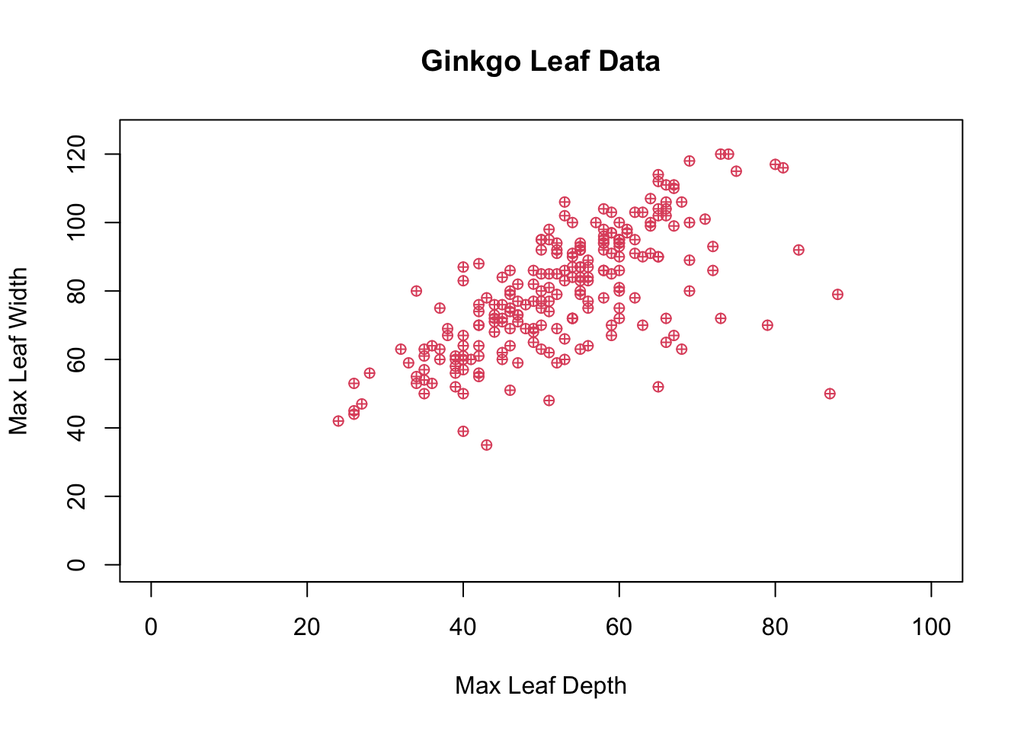

```r
# Scatterplot of ginkgo max leaf depth (x) and max width (y)
# col - describes the color of a point or plot (1 = black, 2 = red, 3 = green)
# pch - describes the shape of each point in a scatterplot (online guides are available)
# cex - describes the point size in comparison to the default (1)
# main - specifies the main title on a graph
# xlab - specifies the x axis title on a graph
# ylab - specifies the y axis title on a graph
# xlim - specifies the x axis limit using a vector of 2 elements
# ylim - specifies teh y axis limit using a vector of 2 elements
plot(ginkgo_df$max_width ~ ginkgo_df$max_depth,
     col = 2,
     pch = 10,
     cex = 0.9,
     main = "Ginkgo Leaf Data",
     xlab = "Max Leaf Depth",
     ylab = "Max Leaf Width",
     xlim = c(0,100),
     ylim = c(0, 125))
```

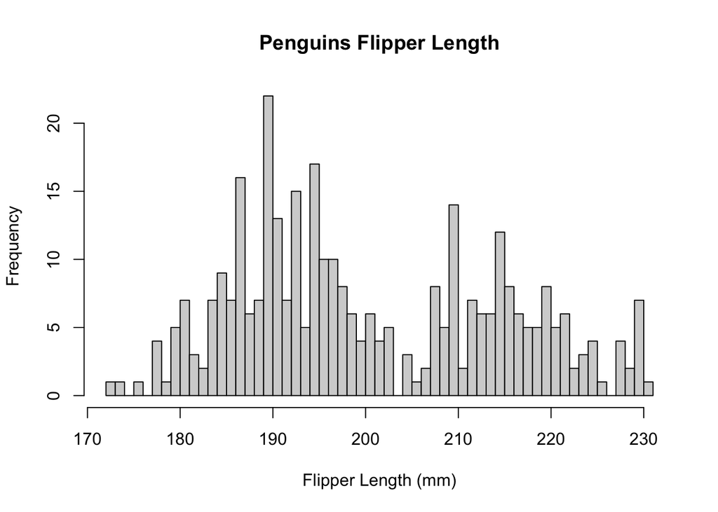

```r
# Histogram of penguin flipper length
# breaks - describes how many bins the data will be separated into in a histogram
hist(penguins$flipper_length_mm,
     main = "Penguins Flipper Length",
     xlab = "Flipper Length (mm)",
     breaks = 50)
```

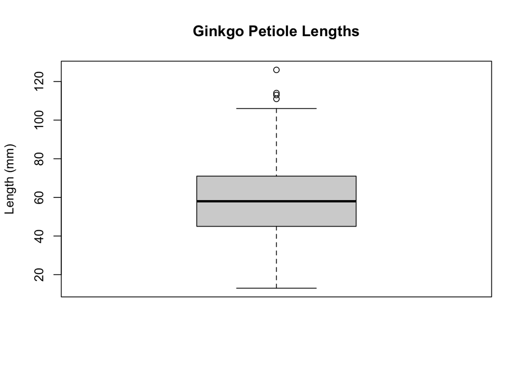

```r
# Boxplot of ginkgo petiole lengths
boxplot(ginkgo_df$petiole_length,
        main = "Ginkgo Petiole Lengths",
        ylab = "Length (mm)")
```

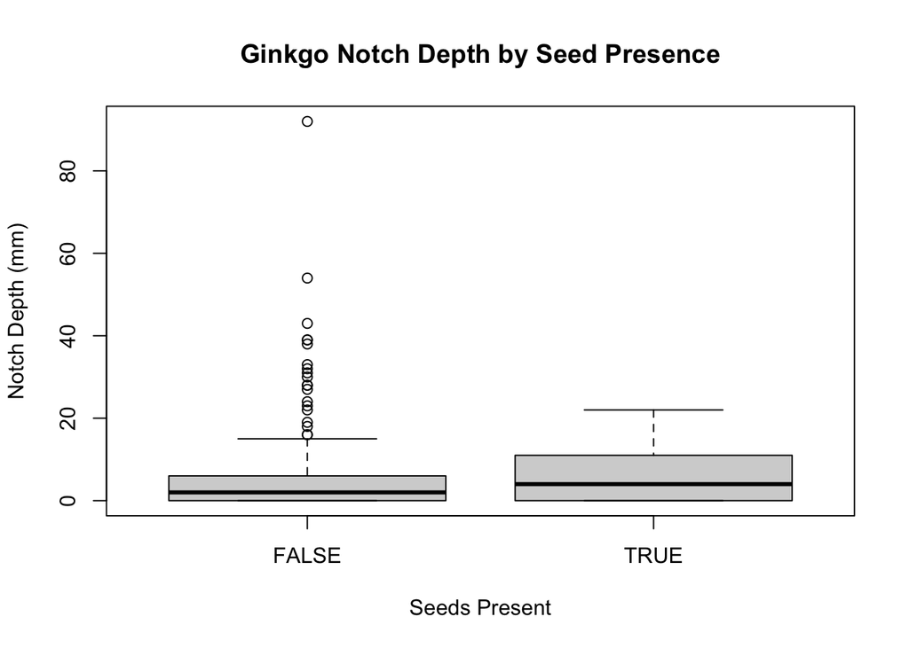

```r
# Boxplot of ginkgo notch depth conditioned on seed presence/absence
boxplot(ginkgo_df$notch_depth ~ ginkgo_df$seeds_present,
        main = "Ginkgo Notch Depth by Seed Presence",
        xlab = "Seeds Present",
        ylab = "Notch Depth (mm)")
```

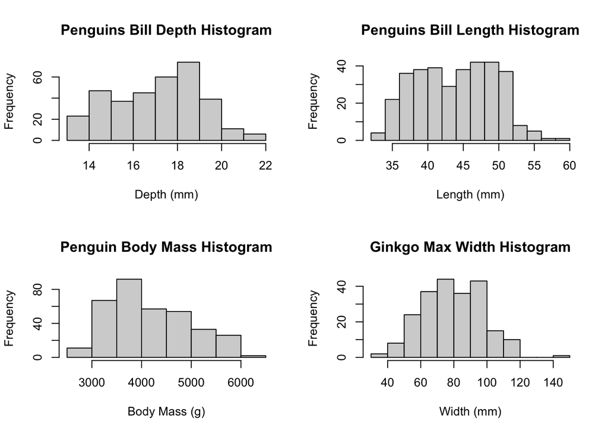

```r
# 4-Panel figure of Histograms
# par(mfrow) - describes the specifications for a multi-panel figure where the vector specifies c(#rows, #columns)
par(mfrow = c(2,2))
hist(penguins$bill_depth_mm,
     main = "Penguins Bill Depth Histogram",
     xlab = "Depth (mm)")
hist(penguins$bill_length_mm,
     main = "Penguins Bill Length Histogram",
     xlab = "Length (mm)")
hist(penguins$body_mass_g,
     main = "Penguin Body Mass Histogram",
     xlab = "Body Mass (g)")
hist(ginkgo_df$max_width,
     main = "Ginkgo Max Width Histogram",
     xlab = "Width (mm)")
```

## Distribution Functions

**dnorm() function - gives the probability of observing a specified value from a normally distributed population.**

```r
# Finding the probability of observing the value 1.2 from a normally distributed population with a mean = 2 and a standard deviation = 2
dnorm(1.2, mean = 2, sd = 2)
```

```
## [1] 0.1841351
```

**pnorm() function - gives the probability of observing on or below a specified value from a normally distributed population.**

```r
# Finding the probability of observing a value less than 1.2 from a normally distributed population with a mean = 2 and a standard deviation = 2
pnorm(1.2, mean = 2, sd = 2)
```

```
## [1] 0.3445783
```

**qnorm() function - gives the value that is the specified percentile from a normally distributed population.**

```r
# Finding the value that is the 85th percentile of a normal distribution with a mean = 70 and standard deviation = 3
qnorm(0.85, mean = 70, sd = 3)
```

```
## [1] 73.1093
```

**dbinom() function - gives the probability of getting a specific number of successes based on the given distribution parameters.**

```r
# Finding the probability of observing a count of exactly 3 successes in a binomial distribution with parameters n = 4 and p = 0.75
dbinom(3, size = 4, prob = 0.75)
```

```
## [1] 0.421875
```

**pbinom() function - gives the probability of getting on or below a specific value based on the given distribution parameters.**

```r
# Finding the probability of observing a count of exactly 3 successes in a binomial distribution with parameters n = 4 and p = 0.75.
pbinom(3, size = 4, prob = 0.75)
```

```
## [1] 0.6835937
```

**qbinom() function - gives the specified quantile of a binomial distribution based on the given distribution parameters.**

```r
# Finding the 10th quantile of a binomial distribution with trials = 10 and p = 0.4
qbinom(0.10, size = 10, prob = 0.4)
```

```
## [1] 2
```